# Human Activity Recognition with caret

```r
library(data.table)
library(tidyr)
library(dplyr)
library(ggplot2)
library(caret)
library(rattle)
library(tictoc)
library(AppliedPredictiveModeling)
library(kableExtra)
```

## Synopsis

The [data](http://groupware.les.inf.puc-rio.br/har) for this project was sourced from the Pontifical Catholic University of Rio de Janeiro (PUC-Rio).$^1$

This project employs the `caret` package in R to build machine learning models that can predict which exercise an individual is performing from wearable sensor data. Sensor data was collected on 4 healthy subjects performing 8 hours of activities. The activities were categorized into 5 classes (sitting-down, standing-up, standing, walking, and sitting).

The repository for this project can be found on my [github](https://github.com/krozic/Human-Activity-Recognition-with-caret).

```r
if(!file.exists('./data')){dir.create('./data')}
fileUrl1 <- 'https://d396qusza40orc.cloudfront.net/predmachlearn/pml-training.csv'
fileUrl2 <- 'https://d396qusza40orc.cloudfront.net/predmachlearn/pml-testing.csv'
if(!file.exists('./data/pml-training.csv')){download.file(fileUrl1, './data/pml-training.csv')}
if(!file.exists('./data/pml-testing.csv')){download.file(fileUrl2, './data/pml-testing.csv')}
```

```r
pml_training <- read.csv('./data/pml-training.csv', na.strings=c('', 'NA', '#DIV/0!'))
pml_testing <- read.csv('./data/pml-testing.csv', na.strings = c('', 'NA', '#DIV/0!'))
```

```r
print(names(pml_training), quote = F)
```

```
##   [1] X                        user_name                raw_timestamp_part_1
##   [4] raw_timestamp_part_2     cvtd_timestamp           new_window
##   [7] num_window               roll_belt                pitch_belt
##  [10] yaw_belt                 total_accel_belt         kurtosis_roll_belt
##  [13] kurtosis_picth_belt      kurtosis_yaw_belt        skewness_roll_belt
##  [16] skewness_roll_belt.1     skewness_yaw_belt        max_roll_belt
##  [19] max_picth_belt           max_yaw_belt             min_roll_belt
##  [22] min_pitch_belt           min_yaw_belt             amplitude_roll_belt
##  [25] amplitude_pitch_belt     amplitude_yaw_belt       var_total_accel_belt
##  [28] avg_roll_belt            stddev_roll_belt         var_roll_belt
##  [31] avg_pitch_belt           stddev_pitch_belt        var_pitch_belt
##  [34] avg_yaw_belt             stddev_yaw_belt          var_yaw_belt
##  [37] gyros_belt_x             gyros_belt_y             gyros_belt_z
##  [40] accel_belt_x             accel_belt_y             accel_belt_z
##  [43] magnet_belt_x            magnet_belt_y            magnet_belt_z
```

[output cut: 39 more lines]

The data contains 160 variables. One of these variables represents the outcome, $classe, while the rest may potentially serve as predictor variables. First I check the integrity of the data, then the data can be prepared for model creation.

## Preparing the Data

### Check integrity of data

Making a contingency table based on the percent of usable data in each variable, I can quickly determine which columns are useful and which are not.

```r
useableData <- table(round(colMeans(!is.na(pml_training))*100, 1))
as.data.table(useableData) %>%
        kbl(col.names = c('% Useable Data', '# of Variables')) %>%
        kable_styling(bootstrap_options = c('striped',
                                            'hover',
                                            'condensed',
                                            'responsive'),
                      full_width = F)
```

**Table 1.** Table showing the count of variables containing the shown amount of useable data.

| % Useable Data | # of Variables |
| --- | --- |
| 0 | 6 |
| 1.6 | 7 |
| 1.7 | 4 |
| 1.9 | 2 |
| 2 | 12 |
| 2.1 | 69 |
| 100 | 60 |

Many variables have < 2% useable data. Additionally, some variables are not meaningful to the excercise being performed (Ex. user_name, timestamps, window). These are removed before any model training is performed.

Also, the outcome variable `$classe` is coerced to a factor.

### Subsetting Data and Partitioning Training/Testing Sets

```r
pml_training$classe <- factor(pml_training$classe)
badCols <- as.vector(colMeans(!is.na(pml_training))*100<5)
pml_training_data <- pml_training[,!badCols]
pml_training_data <- pml_training_data[,-c(1:7)]
pml_testing_data <- pml_testing[,!badCols]
pml_testing_data <- pml_testing_data[,-c(1:7)]
```

```r
set.seed(13415)
inTrain = createDataPartition(pml_training_data$classe,
                              p = 0.6, list = F)
training <- pml_training_data[inTrain,]
testing <- pml_training_data[-inTrain,]
```

`summary()` was used to compare variables in the data and it was found that the distribution of each variable differed greatly from the others. However, feature scaling is not necessary for decision tree type models since they are not sensitive to variance between variables (it will only reduce readability of the data and models).

## Testing Different Models

Since I am predicting a categorical outcome, I used tree predictors and the metric to determine performance was Accuracy (fraction correct), not RMSE or $R^2$. Kappa (measure of concordance) can also be used, however the outcome scenarios are not significantly skewed enough to require normalization of this metric:

```r
prop.table(table(training$classe))
```

```
##
##         A         B         C         D         E
## 0.2843071 0.1935292 0.1744226 0.1638927 0.1838485
```

For model creation I used the `caret` package due to the uniform syntax of the functions between algorithms. (Week 3 of Data Science from JHU (Coursera) describes decision tree models, and I chose to use the models described there.)

I tested four different models:

1. Decision Tree
2. Bootstrap Aggregated Tree (bagging)
3. Random Forest
4. Boosted Model

Cross validation can easily be performed with each algorithm using the `trainControl()` function. For this dataset I used k-fold cross validation. This involves splitting the observations into k-subsets, then removing a subset while training on the remainder for each subset. I’ve chosen to perform 5-fold cross validation here.

```r
trainC <- trainControl(method = 'cv', number = 5)
```

For each model, I trained the model on the `training` data, predicted outcomes on the `testing` data, then analyzed the *out of sample accuracy* of the predictions by running a confusion matrix on predictions and testing outcomes with `confusionMatrix()`. I also measured the time for each model to train using `Sys.time()`.

### 1. Decision Tree

Decision trees estimate a probability per node $m$ for each classification $k$:

$$\hat{P}_{mk} = \frac{1}{N_m}\sum_{i:x_j\in R_m} 1(y_i = k)$$

- Here node $m$ represents region $R_m$, with $N_m$ observations.
- This describes the probability for class $k$ in leaf $m$ - In other words, the number of times class $k$ appears in leaf $m$

```r
set.seed(13415)
start <- Sys.time()
modFitTree <- train(classe ~ .,
                    method = 'rpart',
                    data = training,
                    trControl = trainC)
Treetime <- Sys.time() - start
```

```r
predTree <- predict(modFitTree, newdata = testing)
cmTree <- confusionMatrix(predTree, factor(testing$classe))
cmTree
```

```
## Confusion Matrix and Statistics
##
##           Reference
## Prediction    A    B    C    D    E
##          A 2038  639  659  574  207
##          B   42  517   47  239  206
##          C  147  362  662  473  372
##          D    0    0    0    0    0
##          E    5    0    0    0  657
##
## Overall Statistics
##
##                Accuracy : 0.4938
##                  95% CI : (0.4826, 0.5049)
##     No Information Rate : 0.2845
##     P-Value [Acc > NIR] : < 2.2e-16
##
##                   Kappa : 0.3378
##
##  Mcnemar's Test P-Value : NA
##
## Statistics by Class:
##
##                      Class: A Class: B Class: C Class: D Class: E
## Sensitivity            0.9131  0.34058  0.48392   0.0000  0.45562
## Specificity            0.6297  0.91561  0.79098   1.0000  0.99922
## Pos Pred Value         0.4950  0.49191  0.32837      NaN  0.99245
## Neg Pred Value         0.9480  0.85269  0.87890   0.8361  0.89073
## Prevalence             0.2845  0.19347  0.17436   0.1639  0.18379
## Detection Rate         0.2598  0.06589  0.08437   0.0000  0.08374
## Detection Prevalence   0.5247  0.13395  0.25695   0.0000  0.08437
## Balanced Accuracy      0.7714  0.62810  0.63745   0.5000  0.72742
```

```r
Treetime
```

```
## Time difference of 3.325004 secs
```

It is no surprise that the testing data has such a low out of sample accuracy (49.4%), considering there is no ‘D’ in the prediction model.

### 2. Bootstrap Aggregated Tree (bagging)

This model uses the bootstrap principle to build 25 tree models from separated subsets of the train data, then constructs a final aggregated model which should be more accurate.

```r
set.seed(13415)
start <- Sys.time()
modFitTB <- train(classe ~ .,
                  method = 'treebag',
                  data = training,
                  trControl = trainC)
TBtime <- Sys.time() - start
```

```r
predTB <- predict(modFitTB, newdata = testing)
cmTB <- confusionMatrix(predTB, factor(testing$classe))
cmTB
```

```
## Confusion Matrix and Statistics
##
##           Reference
## Prediction    A    B    C    D    E
##          A 2218   29    1    1    1
##          B    6 1468   16    5    8
##          C    8   12 1337   31    6
##          D    0    8   14 1246    0
##          E    0    1    0    3 1427
##
## Overall Statistics
##
##                Accuracy : 0.9809
##                  95% CI : (0.9776, 0.9838)
##     No Information Rate : 0.2845
##     P-Value [Acc > NIR] : < 2.2e-16
##
##                   Kappa : 0.9758
##
##  Mcnemar's Test P-Value : 2.474e-06
##
## Statistics by Class:
##
##                      Class: A Class: B Class: C Class: D Class: E
## Sensitivity            0.9937   0.9671   0.9773   0.9689   0.9896
## Specificity            0.9943   0.9945   0.9912   0.9966   0.9994
## Pos Pred Value         0.9858   0.9767   0.9591   0.9826   0.9972
## Neg Pred Value         0.9975   0.9921   0.9952   0.9939   0.9977
## Prevalence             0.2845   0.1935   0.1744   0.1639   0.1838
## Detection Rate         0.2827   0.1871   0.1704   0.1588   0.1819
## Detection Prevalence   0.2868   0.1916   0.1777   0.1616   0.1824
## Balanced Accuracy      0.9940   0.9808   0.9843   0.9828   0.9945
```

```r
TBtime
```

```
## Time difference of 33.166 secs
```

The ‘D’ outcome has now been utilized and the out of sample accuracy has increased to 98.1% with a time increase of ~28 seconds

### 3. Random Forest

Random forest not only bootstraps over observations for each tree model, but also bootstraps which variables will be considered when determining the probability at each node.

$$p(c|v) = \frac{1}{T}\sum^{T}_{t}p_t(c|v)$$

$t$ = tree, $T$ = number of trees, $c$ = outcome, $v$ = observation

- $p_t$ is the probability of an outcome $c$ to occur given an observation $v$ for a given tree $t$.
- This probability is averaged over the total number of trees $T$.

```r
set.seed(13415)
start <- Sys.time()
modFitRF <- train(classe ~ .,
                  method = 'rf',
                  ntrees = 25,
                  data = training,
                  trControl = trainC)
RFtime <- Sys.time() - start
```

```r
predRF <- predict(modFitRF, newdata = testing)
cmTB <- confusionMatrix(predRF, factor(testing$classe))
cmTB
```

```
## Confusion Matrix and Statistics
##
##           Reference
## Prediction    A    B    C    D    E
##          A 2226   18    0    0    0
##          B    4 1489   21    0    0
##          C    2   11 1343   29    1
##          D    0    0    4 1255    1
##          E    0    0    0    2 1440
##
## Overall Statistics
##
##                Accuracy : 0.9881
##                  95% CI : (0.9855, 0.9904)
##     No Information Rate : 0.2845
##     P-Value [Acc > NIR] : < 2.2e-16
##
##                   Kappa : 0.985
##
##  Mcnemar's Test P-Value : NA
##
## Statistics by Class:
##
##                      Class: A Class: B Class: C Class: D Class: E
## Sensitivity            0.9973   0.9809   0.9817   0.9759   0.9986
## Specificity            0.9968   0.9960   0.9934   0.9992   0.9997
## Pos Pred Value         0.9920   0.9835   0.9690   0.9960   0.9986
## Neg Pred Value         0.9989   0.9954   0.9961   0.9953   0.9997
## Prevalence             0.2845   0.1935   0.1744   0.1639   0.1838
## Detection Rate         0.2837   0.1898   0.1712   0.1600   0.1835
## Detection Prevalence   0.2860   0.1930   0.1767   0.1606   0.1838
## Balanced Accuracy      0.9971   0.9885   0.9875   0.9876   0.9992
```

```r
RFtime
```

```
## Time difference of 4.8081 mins
```

The random forest model provides a further increase in out of sample accuracy (98.8%) with a time increase of ~4 minutes.

### 4. Boosting with Trees (gbm)

Boosting with trees is similar to ‘Bagging’ in the sense that we are aggregating a large number of classifiers to build a stronger predictor. However, boosting adjusts the weight of an observation based on the last classification:

$$f(x) = sgn\left(\sum_{t = 1}^T\alpha_th_t(x)\right)$$

- If the observation $h_t(x)$ in question was previously classified incorrectly, the weight $\alpha_t$ of the observation will be increased.
- The default number of trees for gbm is 100.

```r
set.seed(13415)
start <- Sys.time()
modFitGBM <- train(classe ~ .,
                   method = 'gbm',
                   data = training,
                   trControl = trainC)
GBMtime <- Sys.time() - start
```

```r
predGBM <- predict(modFitGBM, newdata = testing)
cmGBM <- confusionMatrix(predGBM, factor(testing$classe))
cmGBM
```

```
## Confusion Matrix and Statistics
##
##           Reference
## Prediction    A    B    C    D    E
##          A 2192   56    0    1    2
##          B   28 1410   61    0   14
##          C    8   46 1284   44   14
##          D    3    3   19 1229   14
##          E    1    3    4   12 1398
##
## Overall Statistics
##
##                Accuracy : 0.9576
##                  95% CI : (0.9529, 0.9619)
##     No Information Rate : 0.2845
##     P-Value [Acc > NIR] : < 2.2e-16
##
##                   Kappa : 0.9463
##
##  Mcnemar's Test P-Value : 1.156e-06
##
## Statistics by Class:
##
##                      Class: A Class: B Class: C Class: D Class: E
## Sensitivity            0.9821   0.9289   0.9386   0.9557   0.9695
## Specificity            0.9895   0.9837   0.9827   0.9941   0.9969
## Pos Pred Value         0.9738   0.9319   0.9198   0.9692   0.9859
## Neg Pred Value         0.9929   0.9829   0.9870   0.9913   0.9932
## Prevalence             0.2845   0.1935   0.1744   0.1639   0.1838
## Detection Rate         0.2794   0.1797   0.1637   0.1566   0.1782
## Detection Prevalence   0.2869   0.1928   0.1779   0.1616   0.1807
## Balanced Accuracy      0.9858   0.9563   0.9607   0.9749   0.9832
```

```r
GBMtime
```

```
## Time difference of 2.306483 mins
```

## Model Comparison and Interpretation

After taking a look at the out of sample error rates for each of the models, the random forest model `modFitRF` is found to be the best choice with an accuracy of 98.8% and a kappa of 98.5%.

The top 20 most important variables can be viewed with `varImp(modFitRF)`:

```r
varImp(modFitRF)
```

```
## rf variable importance
##
##   only 20 most important variables shown (out of 52)
##
##                      Overall
## roll_belt             100.00
## yaw_belt               73.10
## magnet_dumbbell_z      66.01
## pitch_forearm          59.96
## magnet_dumbbell_y      59.76
## pitch_belt             57.87
## roll_forearm           53.24
## magnet_dumbbell_x      49.71
## accel_belt_z           43.69
## magnet_belt_z          43.65
## accel_dumbbell_y       42.71
## magnet_belt_y          41.76
## roll_dumbbell          40.87
## accel_dumbbell_z       35.90
## accel_forearm_x        31.95
## roll_arm               31.60
## accel_arm_x            28.81
## accel_dumbbell_x       27.40
## yaw_dumbbell           27.14
## total_accel_dumbbell   27.11
```

It may be useful to determine which variables more strongly contribute to a successful prediction. This information can be used to prune the sensor apparatus to save cost.

For example, there are no ‘gyros’ variables in the top 20 important variables, indicating that this component of the sensor array may not be necessary for successful prediction of exercise type.

### Visualizing important variables in the chosen model

```r
imp_var <- as.data.frame((varImp(modFitRF)[1])$importance)
imp_var <- rownames_to_column(imp_var) %>% arrange(desc(Overall))
imp_data <- training %>% select(imp_var[1:6, 1])
```

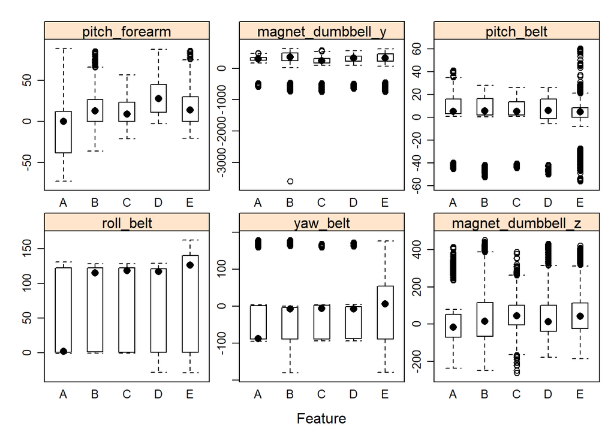

```r
transparentTheme(trans = 0.3)
featurePlot(x = imp_data,
            y = factor(training$classe),
            plot = 'box',
            scales = list(x = list(relation = 'free'),
                          y = list(relation = 'free')),
            auto.key = list(columns = 5)
            )
```

**Figure 1.** Box plots of the top 6 predictors for the random forest model.

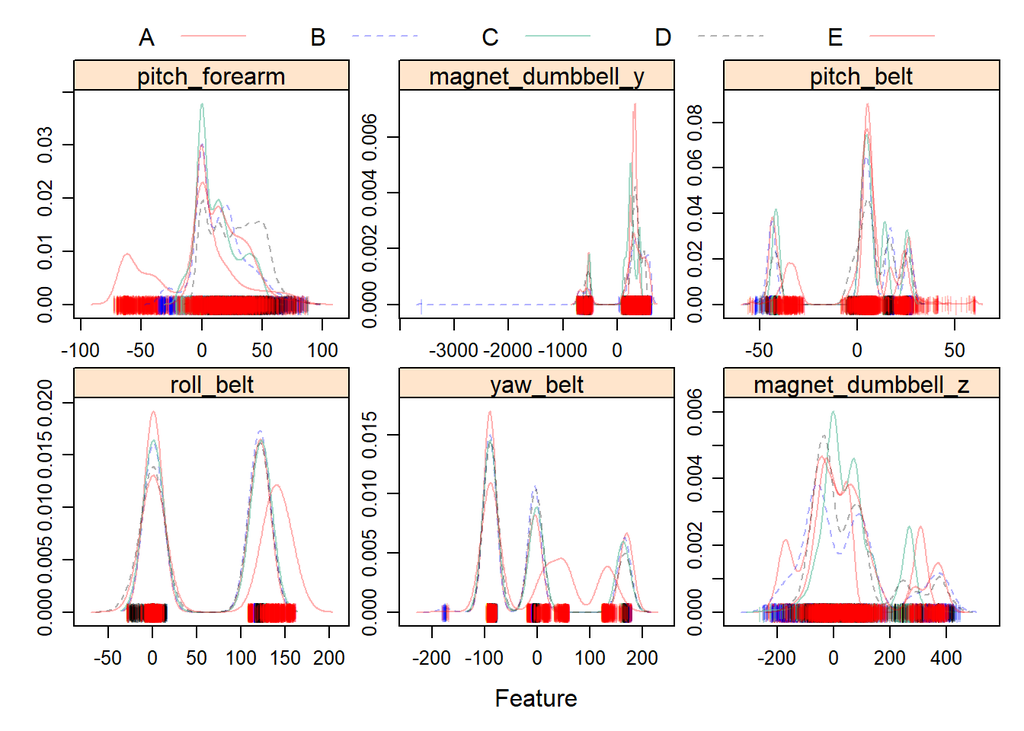

```r
transparentTheme(trans = 0.3)
featurePlot(x = imp_data,
            y = factor(training$classe),
            plot = 'density',
            scales = list(x = list(relation = 'free'),
                          y = list(relation = 'free')),
            pch = '|',
            auto.key = list(columns = 5)
            )
```

**Figure 2.** Density plots of the top 6 predictors for the random forest model.

## Final Prediction on 20 Test Cases

```r
predCases <- predict(modFitRF, newdata = pml_testing_data[,-53])
predCases
```

```
##  [1] B A B A A E D B A A B C B A E E A B B B
## Levels: A B C D E
```

## Conclusion

In conclusion, the random forest model was found to perform the best with an out of sample error rate of 1.2%. The same K-fold cross validation was used to optimize these models, however further optimization of tree numbers for the bagged, random forest, and gbm models could result in higher accuracy using a grid search type cross validation. This would considerably increase the model creation time (hours per model with my hardware), so I chose not to pursue this optimization at this time.

## References

1. Ugulino, W.; Cardador, D.; Vega, K.; Velloso, E.; Milidiu, R.; Fuks, H. Wearable Computing: Accelerometers’ Data Classification of Body Postures and Movements. Proceedings of 21st Brazilian Symposium on Artificial Intelligence. Advances in Artificial Intelligence - SBIA 2012. In: Lecture Notes in Computer Science. , pp. 52-61. Curitiba, PR: Springer Berlin / Heidelberg, 2012. ISBN 978-3-642-34458-9. DOI: 10.1007/978-3-642-34459-6_6.